# Evaluación del equilibrio usando sensores inerciales

Ingeniería Biomédica

Ph.D. Pablo Eduardo Caicedo Rodríguez

2026-09-18

# Algoritmo de procesamiento de señales inerciales

## Introducción

[figure not shown]

## Adquisición de datos

- Se utilizó el sensor XSens MTw Awinda [1].
- Se adquirieron datos de aceleración, giroscopio y magnetómetro.
- Se uso $F_s = 100Hz$.
- Los sensores capturan señales que representan el movimiento en su propio sistema de coordenadas [2].

[figure not shown]

## Adquisición de datos

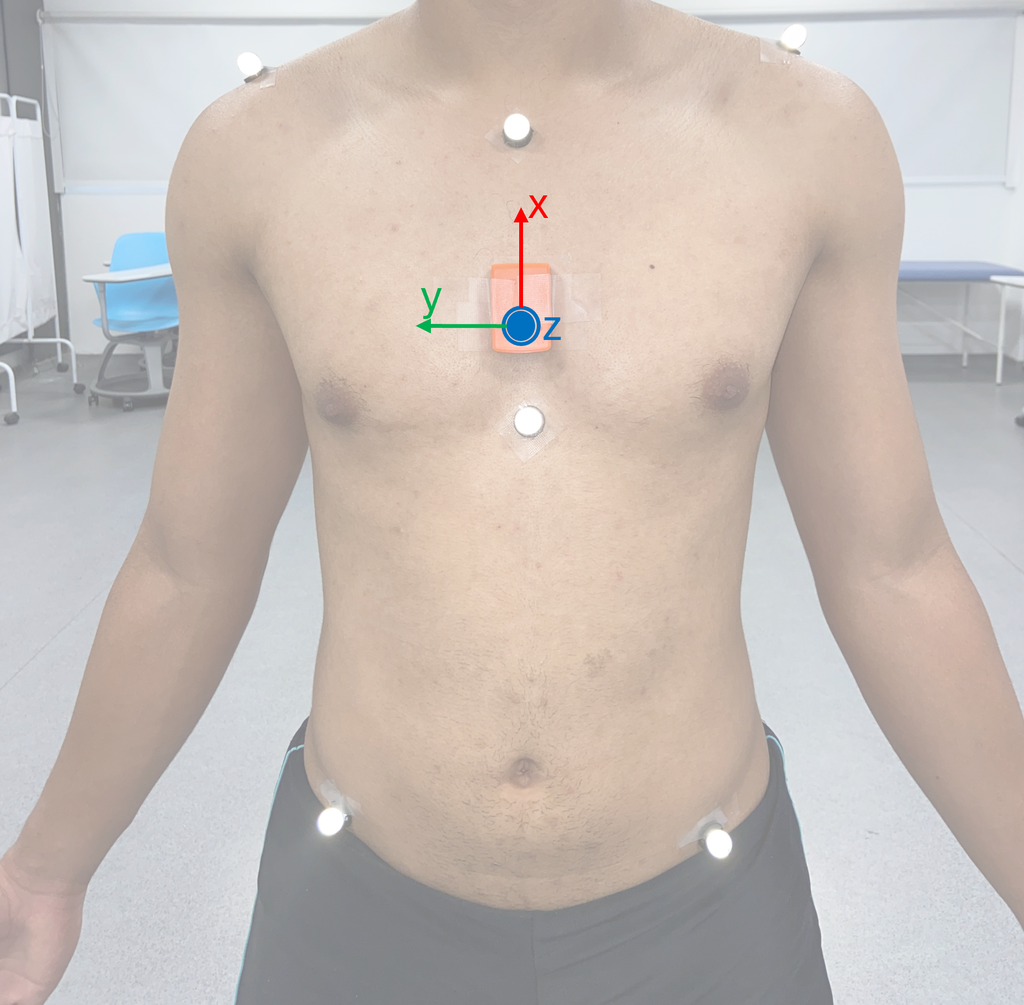

**Datos adquiridos…**

- Protocolo de adquisición modificado [3]
- Actividad con ojos abiertos (eye open), ojos cerrados (eye close) y tarea dual (dual task)

## Preprocesamiento

**Primer paso**

- Eliminación de datos no útiles.
- Datos eliminados: *datos na*, columnas *PacketCounter* y *SampleTimeFine*
- Creación de una columna *Time* en segundos.

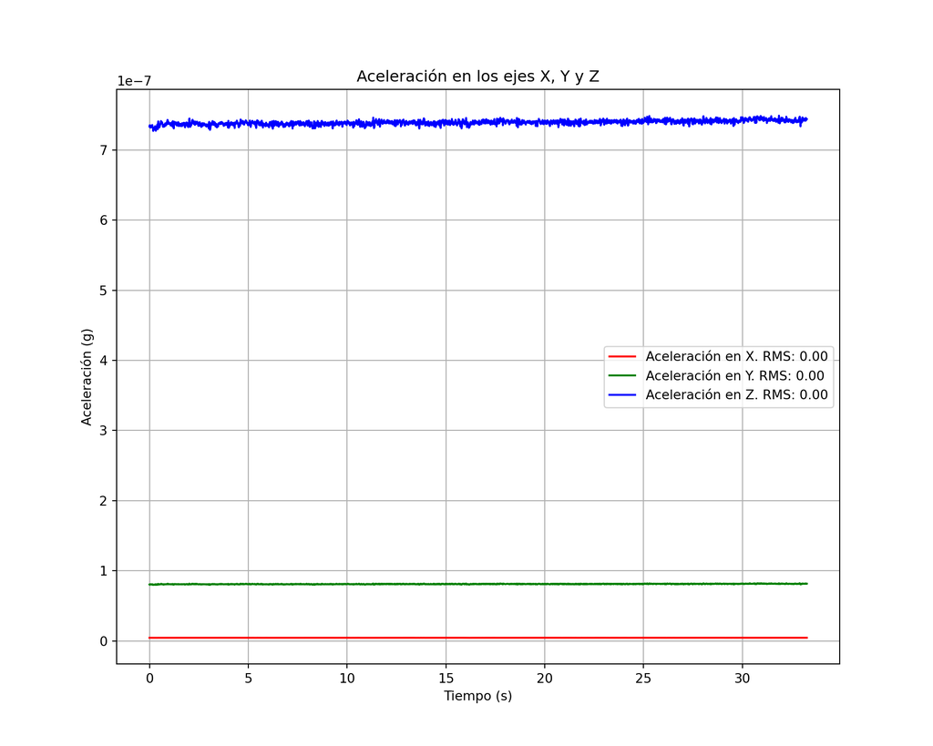

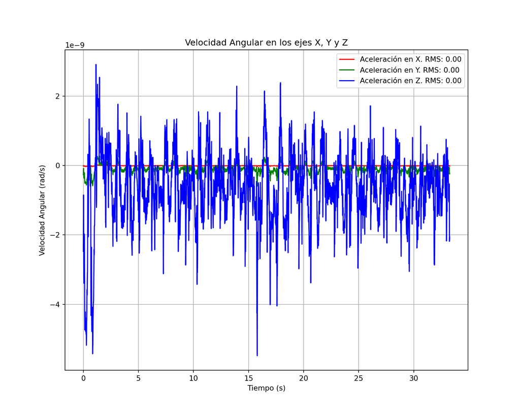

## Preprocesamiento

**Segundo paso**

- Convertir ejes locales a globales. Utilizando el cuaternio generado por el XSens.
- Calcular la magnitud del vector de aceleración global y la agregar al DataFrame.
- Calcular la magnitud del vector de velocidad angular global y la agregar al DataFrame.
- Seleccionar 20 segundos de información (eliminar información inicial y final)

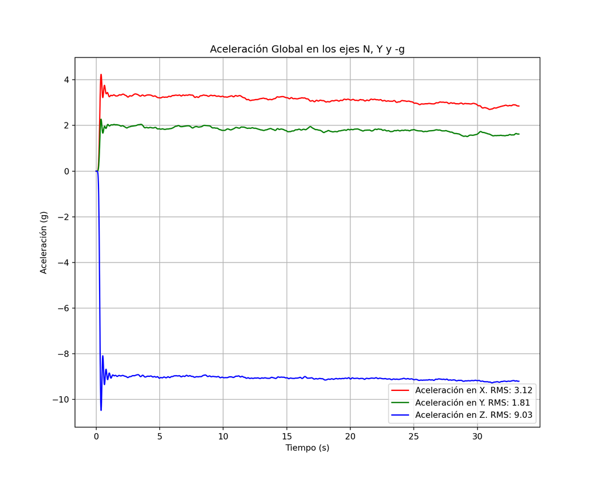

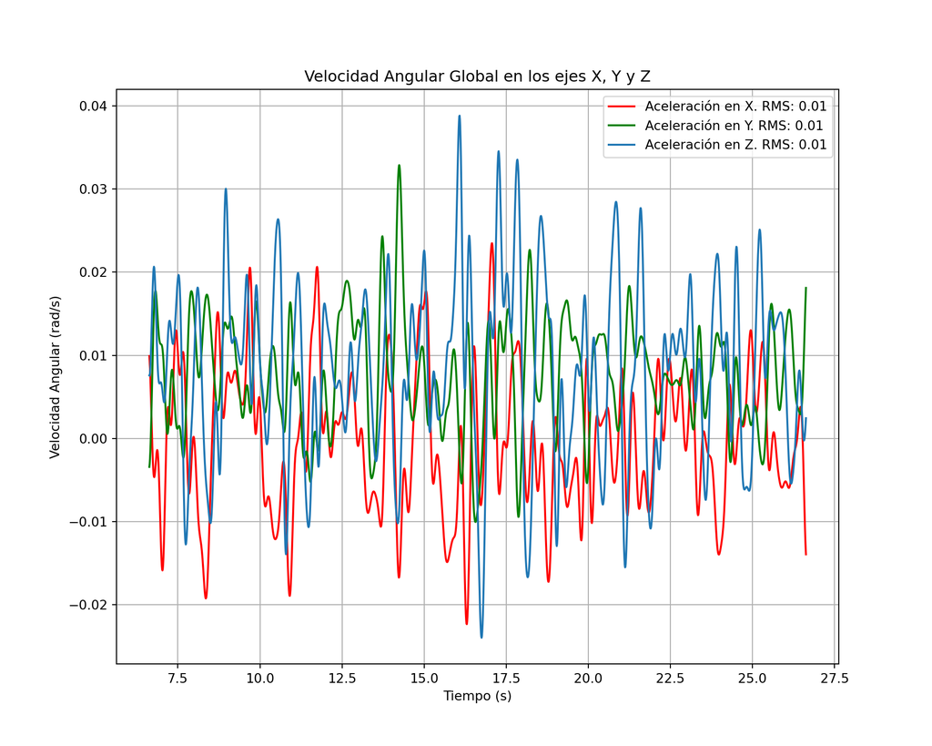

## Fusión sensorial

**Algoritmo de Fusión**

- Se utiliza el algoritmo de la fusión de los datos de aceleración y giroscopio por defecto de XSens.
- Se utiliza el algoritmo de eliminación de distorsión magnética desarrollado por XSens

## Extracción de características

**Métricas**

1. Raíz cuadrática media (RMS) de la magnitud de la aceleración o de la velocidad angular [4].
2. Adaptación de la longitud de la trayectoria [3].
3. Area de de la elipse de oscilación (ellipse sway area), típicamente cubriendo el 95% de los datos presentados.

## Extraccio de características

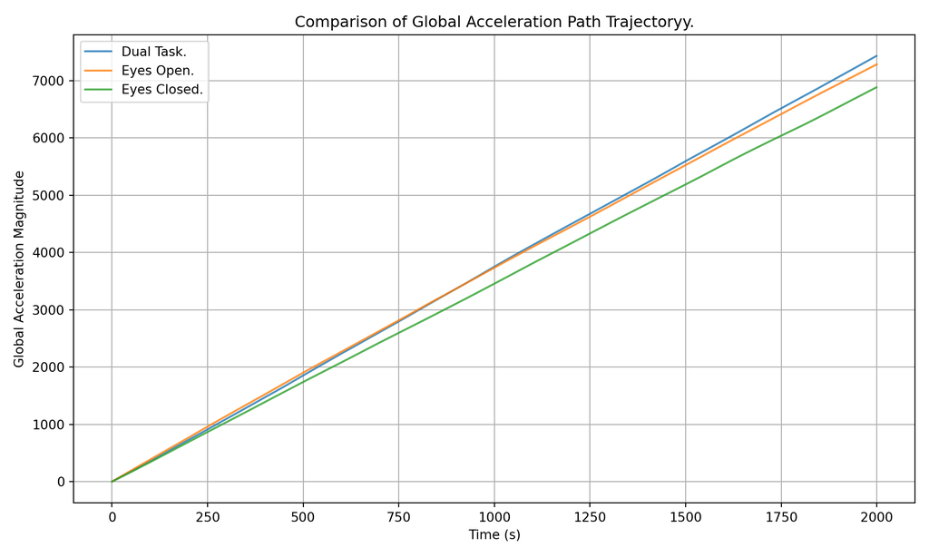

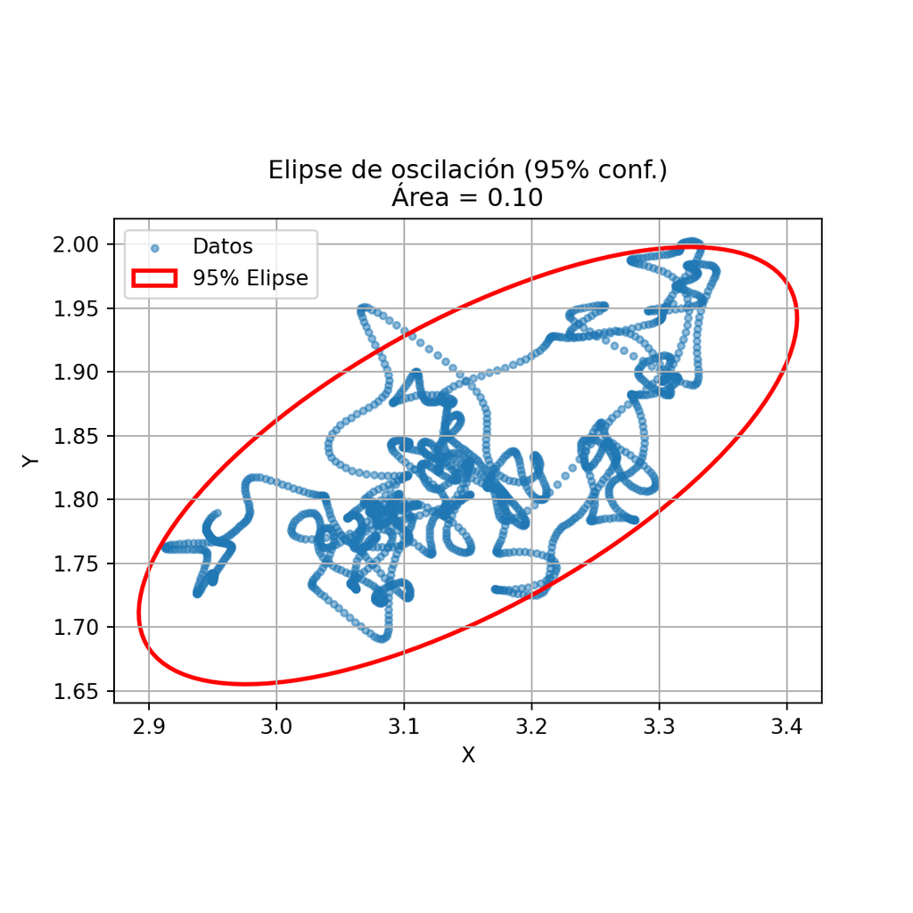

## Extracción de características

**Romberg Ratio**

1. El test de Romberg es una prueba que se usa frecuentemente en la posturografía.
2. Se basa en la evaluación del control postural bajo dos condiciones distintas: con visión (ojos abiertos) y sin visión (ojos cerrados).
3. El índice o ratio de Romberg se calcula dividiendo el balanceo postural (postural sway) en la condición de ojos cerrados entre el balanceo postural en la condición de ojos abiertos.
4. También se puede calcular dividiendo el balanceo postural (postural sway) en la condición de doble tarea entre el balanceo postural en la condición de ojos abiertos

## Extracción de características

|  | Eyes Open | Eyes Close | Dual Task | Ratio Romberg 1 | Ratio Romberg 2 |
| --- | --- | --- | --- | --- | --- |
| RMS ACC X | 2,83E-03 | 2,91E-03 | 2,89E-03 | 1,03 | 1,02 |
| RMS ACC Y | 6,82E-04 | 6,80E-03 | 6,79E-03 | 9,98 | 9,96 |
| RMS ACC Z | 5,74E-04 | 5,08E-04 | 4,98E-04 | 0,89 | 0,87 |
| RMS GYR X | 4,24E-07 | 3,52E-06 | 4,24E-07 | 8,29 | 1,00 |
| RMS GYR Y | 1,02E-05 | 8,27E-06 | 1,16E-05 | 0,81 | 1,14 |
| RMS GYR Z | 8,68E-08 | 6,18E-07 | 8,52E-07 | 7,12 | 9,82 |
| PATH TRAJ | 0,0025 | 0,0025 | 0,0031 | 1,00 | 1,24 |
| AREA_ELIPSE_95% | 5,61E-11 | 8,30E-11 | 6,55E-12 | 1,48 | 0,12 |

## Extracción de características (propuesta)

```
(np.float64(2.7508740895910972), np.float64(3.6048069186140856), np.float64(1.434932874624913), np.float64(2.0295845733092643))
```

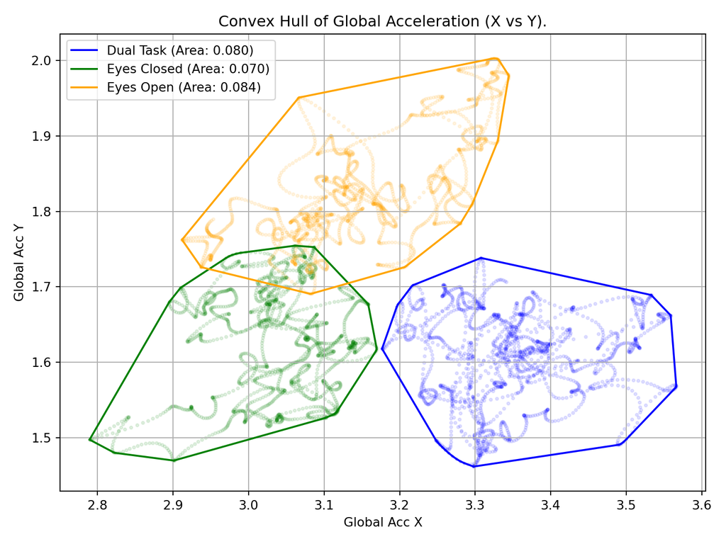

## Referencias

[1]

M. Paulich, M. Schepers, N. Rudigkeit, y G. Bellusci, «Xsens MTw Awinda: Miniature Wireless Inertial-Magnetic Motion Tracker for Highly Accurate 3D Kinematic Applications».

[2]

D. H. Yoon, J.-H. Kim, K. Lee, J.-S. Cho, S.-H. Jang, y S.-U. Lee, «Inertial measurement unit sensor-based gait analysis in adults and older adults: A cross-sectional study», *Gait & Posture*, vol. 107, pp. 212-217, ene. 2024, doi: 10.1016/j.gaitpost.2023.10.006.

[3]

J. Zhou *et al.*, «A novel smartphone App-based assessment of standing postural control: Demonstration of reliability and sensitivity to aging and task constraints», en *2020 IEEE International Conference on E-health Networking, Application & Services (HEALTHCOM)*, Shenzhen, China: IEEE, mar. 2021, pp. 1-6. doi: 10.1109/HEALTHCOM49281.2021.9398972.

[4]

M. Calcagni, P. Kosa, y B. Bielekova, «Smartphone postural sway and pronator drift tests as measures of neurological disability», *BMC Neurol*, vol. 25, n.º 1, p. 50, feb. 2025, doi: 10.1186/s12883-025-04038-2.